# The Relationship between Age at which Adolescents Engage in Risky Behaviors and it’s Effect on their Well-Being

## Modeling Number of Partners

### Multiple Linear Regression Predicting Number of Partners

```r
set.seed(998)
sample <- sample(c(TRUE, FALSE), nrow(data), replace=TRUE, prob=c(0.8,0.2))
traindata4  <- data[sample, ]
testdata4   <- data[!sample, ]
```

```r
model4a <- lm(multiple_partners ~  Age_Alc + Age_Weed + age_sex + race, data=traindata4)
```

```r
summary(model4a)
```

```
##
## Call:
## lm(formula = multiple_partners ~ Age_Alc + Age_Weed + age_sex +
##     race, data = traindata4)
##
## Residuals:
##    Min     1Q Median     3Q    Max
## -4.770 -0.863 -0.067  0.664  4.735
##
## Coefficients:
##                               Estimate Std. Error t value Pr(>|t|)
## (Intercept)                    13.1261     0.2123   61.82  < 2e-16 ***
## Age_Alc                        -0.1264     0.0174   -7.27  4.0e-13 ***
## Age_Weed                       -0.6704     0.0214  -31.34  < 2e-16 ***
## age_sex                        -0.1043     0.0141   -7.40  1.6e-13 ***
## raceBlack or African American   0.9396     0.0586   16.02  < 2e-16 ***
## raceHispanic/Latino            -0.1481     0.0448   -3.31  0.00095 ***
## raceAll Other Races            -0.0681     0.0896   -0.76  0.44706
## ---
## Signif. codes:  0 '***' 0.001 '**' 0.01 '*' 0.05 '.' 0.1 ' ' 1
##
## Residual standard error: 1.41 on 5842 degrees of freedom
## Multiple R-squared:  0.511,  Adjusted R-squared:  0.511
## F-statistic: 1.02e+03 on 6 and 5842 DF,  p-value: <2e-16
```

```r
xkablevif(model4a,"VIF scores")
```

VIF scores

| Age_Alc | age_sex | Age_Weed | raceAll Other Races | raceBlack or African American | raceHispanic/Latino |
| --- | --- | --- | --- | --- | --- |
| 1.87 | 1.31 | 2.6 | 1.12 | 1.9 | 1.4 |

The results of the linear regression model predicting number of sexual partners show that the older an individual is when they start drinking, smoking marijuana, and having romantic relationships, their number of sexual partners decreases. In addition, African American individuals have about 1 more sexual partner in comparison to White individuals, while Hispanic/Latino individuals and individuals of other races have less amount of partners in comparison to White individuals. According to the adjusted R-squared value within the model, race, the ages when an individual started drinking, smoking marijuana, and having romantic relationships explain about ~51% of the variation within number of partners. In addition, the large F-statistic and extremely small p-value lead us to reject the null hypothesis and conclude there is is strong evidence that a relationship does exist between number of sexual partners and our independent variables.

```r
testdata4$modelPredicted4a <- predict(model4a, newdata = testdata4)
```

```r
err0.8 <- testdata4$modelPredicted4a - testdata4$multiple_partners
rmse <- round(sqrt(mean(err0.8^2)),2)
mape <- round(mean(abs(err0.8/testdata4$multiple_partners)),2)

#c <- c(RMSE=rmse,mape=mape,R2=summary(model4a)$r.squared)
#format(c)
x <- summary(model4a)$r.squared
sample_list <- list("Root Mean Square Deviation" = c(rmse), "Mean Absolute Percentage Error" = c(mape),
               "Multiple R2" = round(x, digits = 2))

max_len <- max(lengths(sample_list))
df <- do.call(cbind.data.frame, c(lapply(sample_list, function(x)
               c(x, rep('', max_len - length(x)))), stringsAsFactors = FALSE))

knitr::kable(df,format="simple",align = "c")
```

| Root Mean Square Deviation | Mean Absolute Percentage Error | Multiple R2 |
| --- | --- | --- |
| 1.39 | 0.51 | 0.51 |

### Decision Tree Regression for Number of Partners

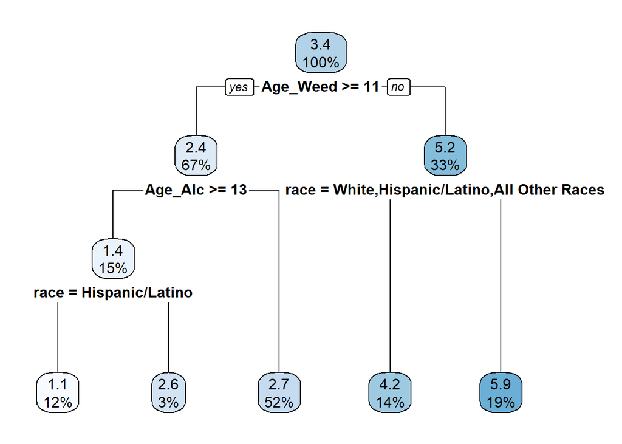

```r
set.seed(998)
sample <- sample(c(TRUE, FALSE), nrow(data), replace=TRUE, prob=c(0.8,0.2))
traindata4  <- data[sample, ]
testdata4   <- data[!sample, ]

model4b<-rpart(formula = multiple_partners ~  Age_Alc + Age_Weed + race, data=traindata4, method = 'anova')
rpart.plot(model4b)
```

```r
testdata4$modelPredicted4b <-predict(model4b, testdata4, type = 'vector')
```

```r
printcp(model4b)
```

```
##
## Regression tree:
## rpart(formula = multiple_partners ~ Age_Alc + Age_Weed + race,
##     data = traindata4, method = "anova")
##
## Variables actually used in tree construction:
## [1] Age_Alc  Age_Weed race
##
## Root node error: 23896/5849 = 4
##
## n= 5849
##
##     CP nsplit rel error xerror  xstd
## 1 0.41      0       1.0    1.0 0.008
## 2 0.05      1       0.6    0.6 0.012
## 3 0.05      2       0.5    0.5 0.011
## 4 0.01      3       0.5    0.5 0.011
## 5 0.01      4       0.5    0.5 0.010
```

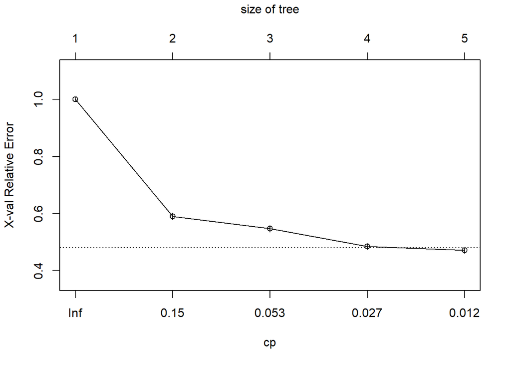

```r
plotcp(model4b)
```

```r
p <- predict(model4b, traindata4)
rmse <- sqrt(mean((traindata4$multiple_partners-p)^2))  #RMSE
r2 <- (cor(traindata4$multiple_partners, p))^2        #R-Square

sample_list <- list("Root Mean Square Deviation" = round(rmse, digits = 2),
               "Multiple R2" = round(r2, digits = 2))

max_len <- max(lengths(sample_list))
df <- do.call(cbind.data.frame, c(lapply(sample_list, function(x)
               c(x, rep('', max_len - length(x)))), stringsAsFactors = FALSE))

knitr::kable(df,format="simple",align = "c")
```

| Root Mean Square Deviation | Multiple R2 |
| --- | --- |
| 1.39 | 0.53 |

The overall average for number of sexual partners for the sample is about 3.4 partners. The rules of the decision tree indicate that individuals who started smoking marijuana on or after age 11 and started drinking before the age of 13 have about 2.7 partners (52% of the respondents fall under this category) on average. Individuals who started smoking marijuana on or after age 11, started drinking after the age of 13 and are Hispanic/Latino have about 1.1 partners (12% of the respondents fall under this category) on average while those who are not Hispanic/Latino have 2.6 partners on average. For individuals who started smoking marijuana before age 11 and are White, Hispanic or All other races have 4.2 partners (14% of the respondents fall under this category) on average while those who are Black or African American have almost 6 partners (19% of the respondents fall under this category) on average.

### Random Forest Regression for Number of Partners

```r
set.seed(998)
sample <- sample(c(TRUE, FALSE), nrow(data), replace=TRUE, prob=c(0.8,0.2))
traindata4  <- data[sample, ]
testdata4   <- data[!sample, ]
```

```r
model4c<-randomForest(formula = multiple_partners ~  Age_Alc + Age_Weed + age_sex + race, data = traindata4, proximity=TRUE, type='regression', na.action=na.exclude)
print(model4c)
```

```
##
## Call:
##  randomForest(formula = multiple_partners ~ Age_Alc + Age_Weed +      age_sex + race, data = traindata4, proximity = TRUE, type = "regression",      na.action = na.exclude)
##                Type of random forest: regression
##                      Number of trees: 500
## No. of variables tried at each split: 1
##
##           Mean of squared residuals: 1.53
##                     % Var explained: 62.5
```

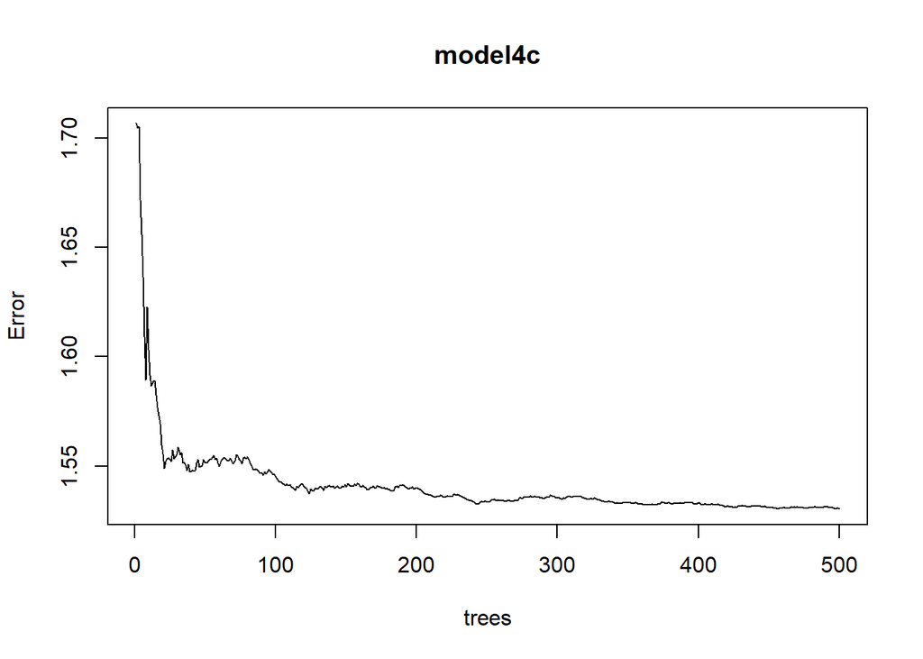

```r
testdata4$modelPredicted4c <-predict(model4c, testdata4)
plot(model4c)
```

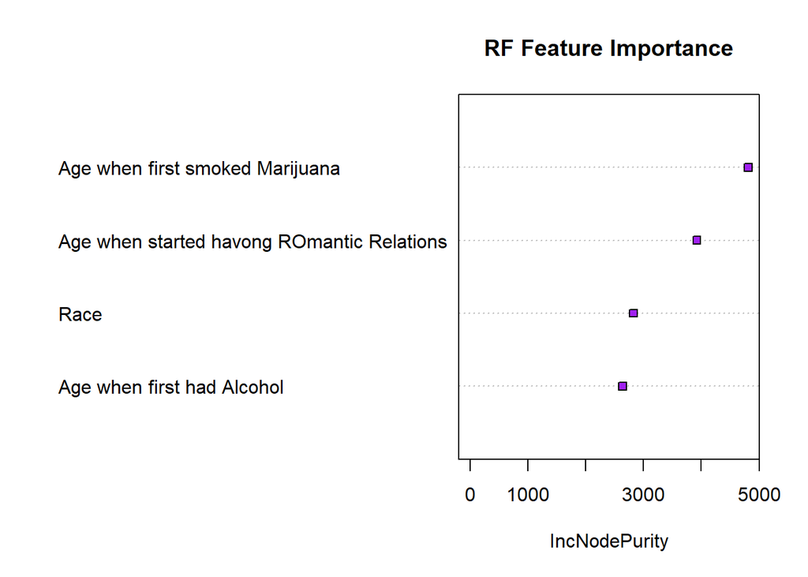

```r
varImpPlot(model4c, bg = "purple", cex=1, pch=22, main="RF Feature Importance", labels = c("Age when first had Alcohol", "Race", "Age when started havong ROmantic Relations", "Age when first smoked Marijuana"))
```

If you drop Age when first smoked Marijuana and Age when started having Romantic Relations from the model, it’s prediction power will greatly reduce. On the other hand if we reduce variables like Race and Age when first had alcohol, there might be some impact on prediction power of the model.

```r
p <- predict(model4c, traindata4)
rmse <- sqrt(mean((traindata4$multiple_partners-p)^2))  #RMSE
r2 <- (cor(traindata4$multiple_partners, p))^2        #R-Square

sample_list <- list("Root Mean Square Deviation" = round(rmse, digits = 2),
               "Multiple R2" = round(r2, digits = 2))

max_len <- max(lengths(sample_list))
df <- do.call(cbind.data.frame, c(lapply(sample_list, function(x)
               c(x, rep('', max_len - length(x)))), stringsAsFactors = FALSE))

knitr::kable(df,format="simple",align = "c")
```

| Root Mean Square Deviation | Multiple R2 |
| --- | --- |
| 1.21 | 0.65 |

## Modeling Days of Physical Activity

### Multiple Linear Regression Predicting Physical Activity

```r
set.seed(1027)
sample <- sample(c(TRUE, FALSE), nrow(data), replace=TRUE, prob=c(0.8,0.2))
traindata5  <- data[sample, ]
testdata5   <- data[!sample, ]
```

```r
model5a <- lm(physical_activity ~  Age_Alc + Age_Weed + age_sex + race, data=traindata5)
summary(model5a)
```

```
##
## Call:
## lm(formula = physical_activity ~ Age_Alc + Age_Weed + age_sex +
##     race, data = traindata5)
##
## Residuals:
##    Min     1Q Median     3Q    Max
##  -7.18  -1.09   0.71   1.46   4.25
##
## Coefficients:
##                               Estimate Std. Error t value Pr(>|t|)
## (Intercept)                     6.1565     0.3441   17.89  < 2e-16 ***
## Age_Alc                         0.1232     0.0281    4.39  1.2e-05 ***
## Age_Weed                       -0.4152     0.0346  -11.98  < 2e-16 ***
## age_sex                         0.0951     0.0228    4.16  3.2e-05 ***
## raceBlack or African American   1.6869     0.0949   17.78  < 2e-16 ***
## raceHispanic/Latino             1.9401     0.0721   26.91  < 2e-16 ***
## raceAll Other Races             0.1412     0.1447    0.98     0.33
## ---
## Signif. codes:  0 '***' 0.001 '**' 0.01 '*' 0.05 '.' 0.1 ' ' 1
##
## Residual standard error: 2.26 on 5762 degrees of freedom
## Multiple R-squared:  0.177,  Adjusted R-squared:  0.176
## F-statistic:  207 on 6 and 5762 DF,  p-value: <2e-16
```

The results of the linear regression predicting number of days of physical activity indicate that for each year older an individual is when they start drinking alcohol and having romantic relationships, their amount of physical activity per week increases by 0.12 and 0.10 of a day respectively. For each year older an individual is when they start smoking Marijuana, their amount of physical activity per week decreases by 0.42 of a day. African American individuals engage in physical activity 1.6 more days week than White individuals while Hispanic/Latino individuals engage in physical activity almost 2 more days a week than White individuals.According to the adjusted R-squared value within the model, race, the ages when an individual started drinking, smoking marijuana, and having romantic relationships explain about ~18% of the variation within number of days of physical activity per week. In addition, the large F-statistic and extremely small p-value lead us to reject the null hypothesis and conclude there is is strong evidence that a relationship does exist between days of physical activtiy per week and our independent variables.

```r
xkablevif(model5a)
```

VIFs of Model: physical_activity ~ Age_Alc + Age_Weed + age_sex + race

| Age_Alc | age_sex | Age_Weed | raceAll Other Races | raceBlack or African American | raceHispanic/Latino |
| --- | --- | --- | --- | --- | --- |
| 1.89 | 1.31 | 2.63 | 1.11 | 1.91 | 1.4 |

```r
testdata5$modelPredicted5a <- predict(model5a, newdata = testdata5)
```

```r
err0.8 <- testdata5$modelPredicted5a - testdata5$physical_activity
rmse <- sqrt(mean(err0.8^2))
mape <- mean(abs(err0.8/testdata5$physical_activity))

#c(RMSE=rmse,mape=mape,R2=summary(model5a)$r.squared)

x <- summary(model5a)$r.squared
sample_list <- list("Root Mean Square Deviation" = round(rmse, digits = 2), "Mean Absolute Percentage Error" = c(mape),
               "Multiple R2" = round(x, digits = 2))

max_len <- max(lengths(sample_list))
df <- do.call(cbind.data.frame, c(lapply(sample_list, function(x)
               c(x, rep('', max_len - length(x)))), stringsAsFactors = FALSE))

knitr::kable(df,format="simple",align = "c")
```

| Root Mean Square Deviation | Mean Absolute Percentage Error | Multiple R2 |
| --- | --- | --- |
| 2.32 | Inf | 0.18 |